# Empirical Finance: Tutorial - Week 3

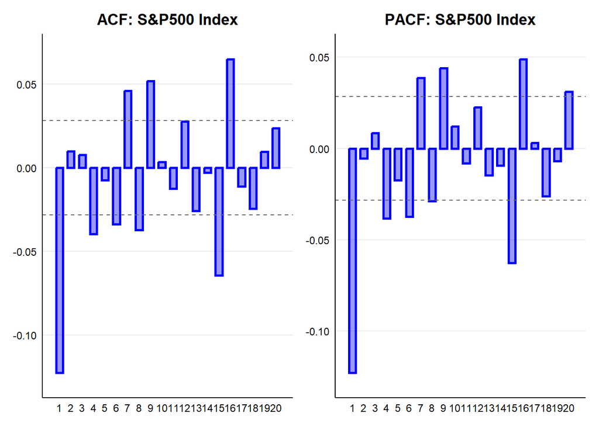

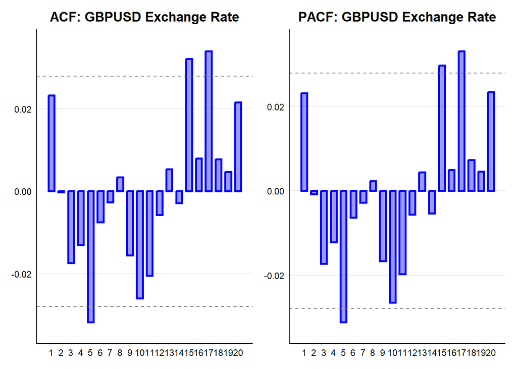

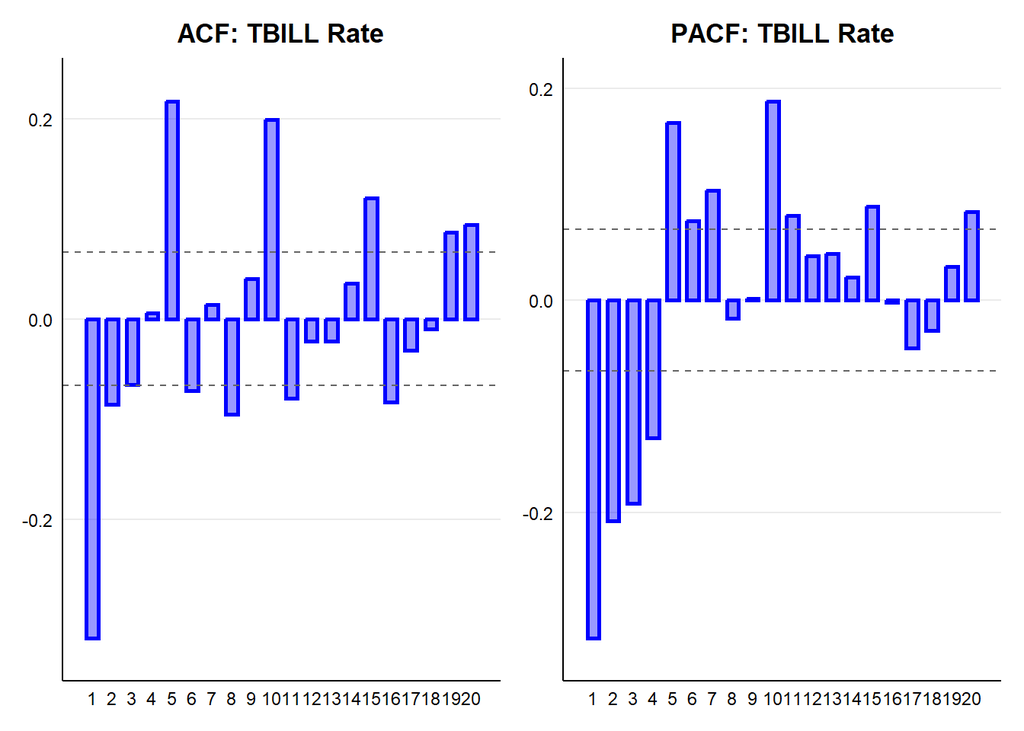

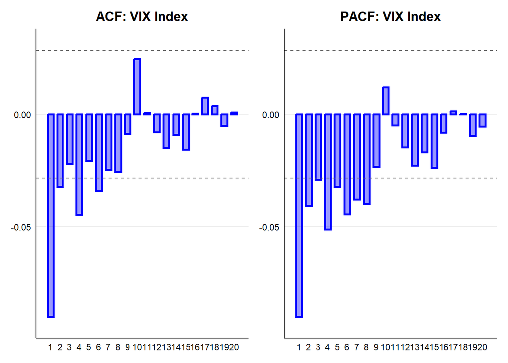

```r
lapply(names(time_series_list), function(name) {

  time_series <- time_series_list[[name]]

  # if (name == "TBILL") {
  #
  #   # par(mfrow = c(1, 2))
  #   # acf(na.omit(time_series$TBILL) , main = paste("ACF:", name))
  #   # pacf(na.omit(time_series$TBILL), main = paste("PACF:", name))
  #
  #   nice_acf(time_series, "TBILL", name, lag.max = 20) + nice_pacf(time_series, "TBILL", name, lag.max = 20)
  #
  # } else {

    # par(mfrow = c(1, 2))
    # acf(na.omit(time_series$lr) , main = paste("ACF:", name))
    # pacf(na.omit(time_series$lr), main = paste("PACF:", name))

    nice_acf(time_series, "lr", name, lag.max = 20) + nice_pacf(time_series, "lr", name, lag.max = 20)

  # }
})
```

### Augmented Dickey–Fuller Test

We can use this test to evaluate whether a time series is stationary.

**Decision rule:** *p*-value < 0.05, reject $H_0$ in favor of the alternative (i.e. the series is stationary)

```r
lapply(time_series_list, function(ts){
  adf.test(na.omit(ts$lr))
})
```

```
## $SP500
##
##  Augmented Dickey-Fuller Test
##
## data:  na.omit(ts$lr)
## Dickey-Fuller = -17.016, Lag order = 16, p-value = 0.01
## alternative hypothesis: stationary
##
##
## $GBPUSD
##
##  Augmented Dickey-Fuller Test
##
## data:  na.omit(ts$lr)
## Dickey-Fuller = -16.275, Lag order = 17, p-value = 0.01
## alternative hypothesis: stationary
##
##
## $TBILL
##
##  Augmented Dickey-Fuller Test
##
## data:  na.omit(ts$lr)
## Dickey-Fuller = -7.898, Lag order = 9, p-value = 0.01
## alternative hypothesis: stationary
##
##
## $VIX
##
##  Augmented Dickey-Fuller Test
##
## data:  na.omit(ts$lr)
## Dickey-Fuller = -19.372, Lag order = 16, p-value = 0.01
## alternative hypothesis: stationary
```

We can sucessfully conclude that we have imposed stationary across our series, as the p-value sits below the 5% mark.

## Fitting the Best Model

**How do we choose $p$ and $q$?**

The selection of the autoregressive order $p$ and the moving-average order $q$ typically follows a structured, iterative approach.

**1) Ensure stationarity of the time series** If the series is not stationary, it must be transformed before model estimation.

- Apply first differencing when necessary.
- In the case of asset prices, work with log returns, which already correspond to first differences of log prices and are therefore typically stationary.

**2) Form an initial guess for $p$ and $q$** Preliminary identification of the model orders can be guided by the autocorrelation structure of the data.

- Use the autocorrelation function (ACF) and the partial autocorrelation function (PACF) to obtain indications of whether an AR, MA, or ARMA specification is appropriate, and to suggest plausible lag lengths.

**3) Estimate the model** Estimate the candidate model(s) identified in the previous step.

- Fit the ARMA($p, q$) specification(s) that appear most consistent with the observed ACF and PACF patterns.

**4) Perform model diagnostics** Model adequacy is assessed using both information criteria and residual diagnostics.

**Information criteria**

- Information criteria balance goodness of fit against model complexity.
- They help determine whether a more parsimonious specification provides a comparable or superior fit.
- They guide the choice of the optimal number of lags.
- Commonly used criteria include the Akaike Information Criterion (AIC) and the Bayesian (Schwarz) Information Criterion (BIC); the preferred model is the one with the lowest value.

**Test for serial correlation**

- In a correctly specified ARMA model, the residuals should be white noise, meaning they are serially uncorrelated and capture only unpredictable shocks.
- Testing for residual autocorrelation is therefore essential to validate the model.
- Apply the Ljung–Box (Q-statistic) test to the residuals. Failure to reject the null hypothesis of no serial correlation indicates that the residuals are consistent with white noise and that the model specification is adequate.

### S&P500 Index

```r
# --- fit an ARMA(1,1)
SP500_model <- arima(SP500$lr, order = c(1,0,1))
summary(SP500_model)
```

```
##
## Call:
## arima(x = SP500$lr, order = c(1, 0, 1))
##
## Coefficients:
##           ar1      ma1  intercept
##       -0.0632  -0.0601      3e-04
## s.e.   0.1165   0.1162      2e-04
##
## sigma^2 estimated as 0.0001545:  log likelihood = 14225.94,  aic = -28443.88
##
## Training set error measures:
##                         ME       RMSE         MAE  MPE MAPE      MASE
## Training set -2.412384e-07 0.01243021 0.008014182 -Inf  Inf 0.6665894
##                       ACF1
## Training set -9.670274e-05
```

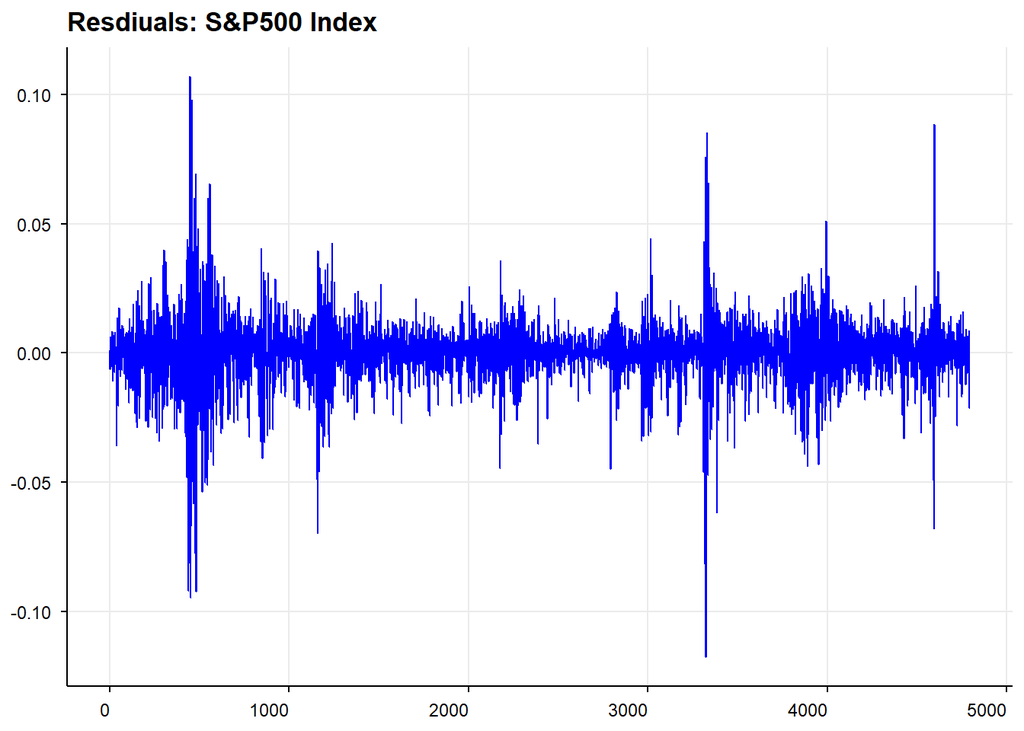

```r
# --- plot the residuals
plot_res(SP500_model, "SP500")
```

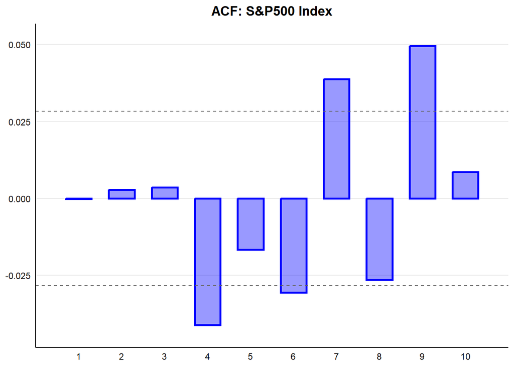

```r
# --- plot the ACF of the residuals
nice_acf(residuals(SP500_model),"SP500", residuals = TRUE)
```

```r
# --- Ljung-Box test (p-value > 0.05, fail to reject the null, residuals look like WN)
Box.test(residuals(SP500_model), lag=20, type = "Ljung-Box")
```

```
##
##  Box-Ljung test
##
## data:  residuals(SP500_model)
## X-squared = 82.269, df = 20, p-value = 1.612e-09
```

```r
# --- own automated loop to select p and q
fit_arma(SP500$lr)
```

```
## $aic
## [1] -28458.63
##
## $order
## [1] 4 0 3
##
## $model
##
## Call:
## arima(x = ts, order = final.order)
##
## Coefficients:
##          ar1     ar2      ar3      ar4      ma1      ma2     ma3  intercept
##       0.5220  0.3831  -0.6375  -0.1303  -0.6479  -0.3155  0.6944      3e-04
## s.e.  0.0894  0.0967   0.0780   0.0154   0.0895   0.1011  0.0837      2e-04
##
## sigma^2 estimated as 0.0001537:  log likelihood = 14238.32,  aic = -28458.63
```

```r
# --- forecast package function
auto.arima(SP500$lr, ic = "aic")
```

```
## Series: SP500$lr
## ARIMA(0,0,1) with non-zero mean
##
## Coefficients:
##           ma1   mean
##       -0.1221  3e-04
## s.e.   0.0142  2e-04
##
## sigma^2 = 0.0001546:  log likelihood = 14225.71
## AIC=-28445.41   AICc=-28445.41   BIC=-28425.99
```

There are some significant peaks in the ACF of the residuals, especially at higher lags. This is indicative of a poor fit.

If we try the Ljung-Box test, we have statistical evidence for this.

### GBPUSD Exchange Rate

```r
# --- fit an ARMA(1,1)
GBPUSD_model <- arima(GBPUSD$lr, order = c(0,0,0))
summary(GBPUSD_model)
```

```
##
## Call:
## arima(x = GBPUSD$lr, order = c(0, 0, 0))
##
## Coefficients:
##       intercept
##          -1e-04
## s.e.      1e-04
##
## sigma^2 estimated as 3.52e-05:  log likelihood = 18308.19,  aic = -36612.38
##
## Training set error measures:
##                         ME        RMSE        MAE MPE MAPE      MASE       ACF1
## Training set -3.751243e-16 0.005932543 0.00424065 Inf  Inf 0.6913998 0.02270792
```

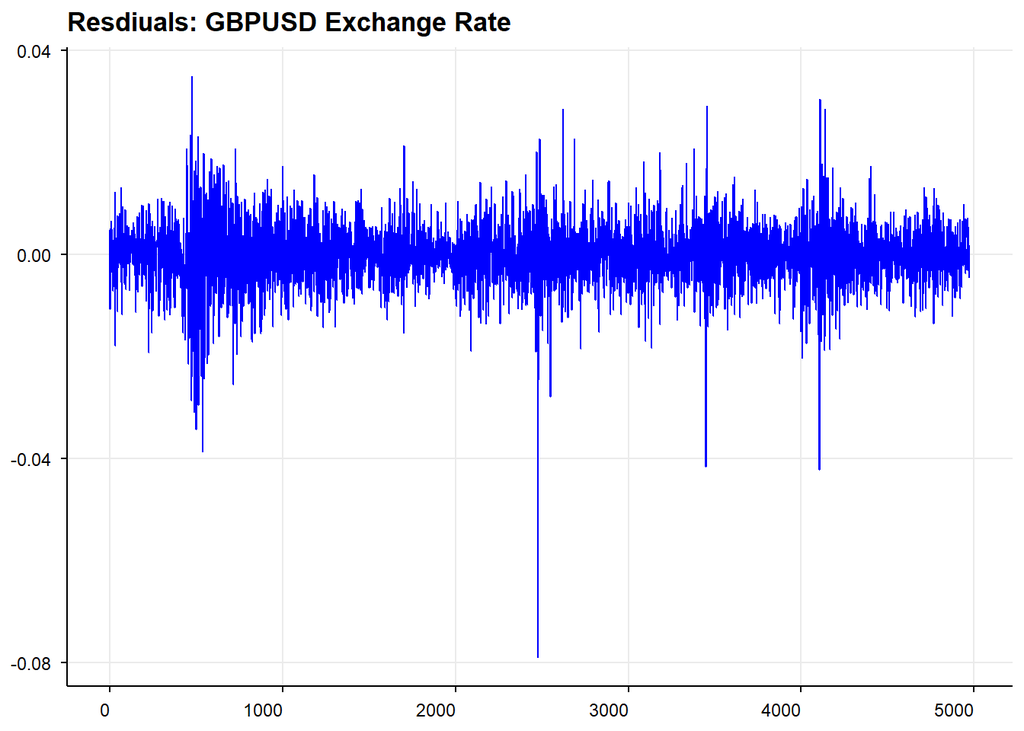

```r
# --- plot the residuals
plot_res(GBPUSD_model, "GBPUSD")
```

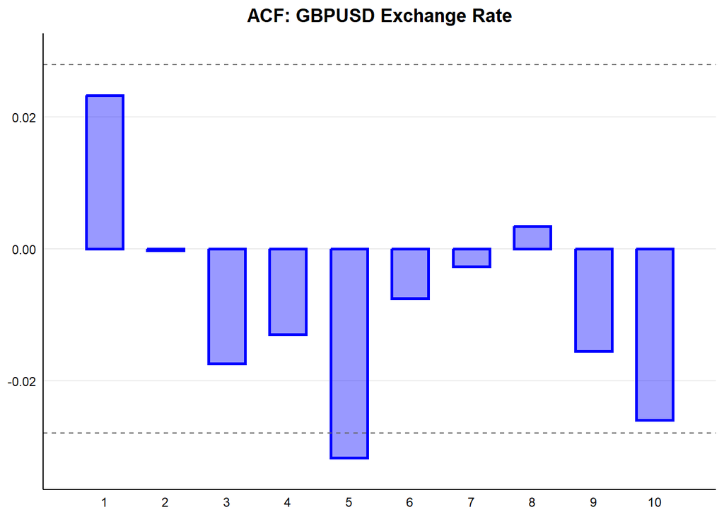

```r
# --- plot the ACF of the residuals
nice_acf(residuals(GBPUSD_model),"GBPUSD", residuals = TRUE)
```

```r
# --- Ljung-Box test (p-value > 0.05, fail to reject the null, residuals look like WN)
Box.test(residuals(GBPUSD_model), lag=20, type = "Ljung-Box")
```

```
##
##  Box-Ljung test
##
## data:  residuals(GBPUSD_model)
## X-squared = 30.205, df = 20, p-value = 0.06659
```

```r
# --- own automated loop to select p and q
fit_arma(GBPUSD$lr)
```

```
## $aic
## [1] -36616.43
##
## $order
## [1] 4 0 4
##
## $model
##
## Call:
## arima(x = ts, order = final.order)
##
## Coefficients:
```

```
##          ar1     ar2    ar3      ar4      ma1      ma2      ma3     ma4
##       0.3325  0.8162  0.254  -0.8747  -0.3165  -0.8165  -0.2714  0.8646
## s.e.     NaN     NaN    NaN   0.0486      NaN      NaN      NaN  0.0478
##       intercept
##          -1e-04
## s.e.      1e-04
##
## sigma^2 estimated as 3.505e-05:  log likelihood = 18318.21,  aic = -36616.43
```

```r
# --- forecast package function
auto.arima(GBPUSD$lr, ic = "aic")
```

```
## Series: GBPUSD$lr
## ARIMA(3,0,2) with non-zero mean
##
## Coefficients:
##          ar1     ar2      ar3      ma1      ma2    mean
##       0.1897  0.5344  -0.0372  -0.1677  -0.5437  -1e-04
## s.e.  0.4796  0.4202   0.0168   0.4800   0.4165   1e-04
##
## sigma^2 = 3.518e-05:  log likelihood = 18312.47
## AIC=-36610.95   AICc=-36610.92   BIC=-36565.36
```

Our `fit_arma` function seems to disagree with our visual inspection choice. This should not surprise us, because this function is the designed to find the (p,q) pair with the lowest AIC. Stil, it seems we have found a good fit, as the we fail to reject the null in the Ljung-Box text.

### TBILL Rate

```r
# --- fit an ARMA(3,3)
TBILL_model <- arima(TBILL$lr, order = c(3,0,3))
summary(TBILL_model)
```

```
##
## Call:
## arima(x = TBILL$lr, order = c(3, 0, 3))
##
## Coefficients:
##          ar1      ar2      ar3      ma1     ma2      ma3  intercept
##       0.3804  -0.8806  -0.1235  -0.8297  1.0197  -0.3137     0.0083
## s.e.  0.0774   0.0477   0.0689   0.0725  0.0607   0.0626     0.0002
##
## sigma^2 estimated as 6.962e-05:  log likelihood = 2912.26,  aic = -5808.52
##
## Training set error measures:
##                        ME        RMSE         MAE MPE MAPE      MASE
## Training set 1.757282e-06 0.008344143 0.006581097 NaN  Inf 0.5442137
##                      ACF1
## Training set -0.002879545
```

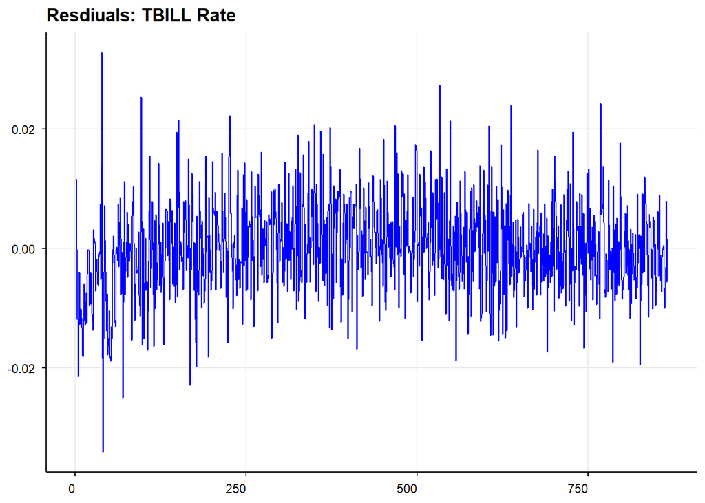

```r
# --- plot the residuals
plot_res(TBILL_model, "TBILL")
```

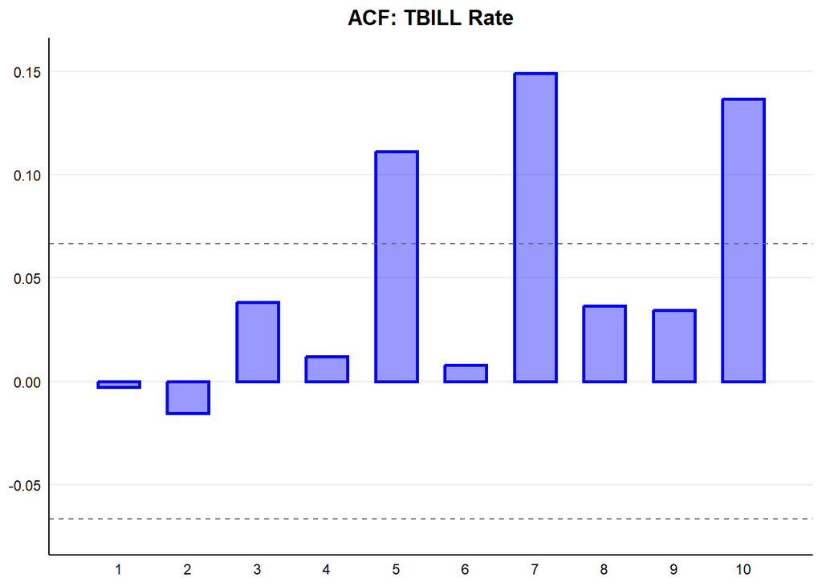

```r
# --- plot the ACF of the residuals
nice_acf(residuals(TBILL_model),"TBILL", residuals = TRUE)
```

```r
# --- Ljung-Box test (p-value > 0.05, fail to reject the null, residuals look like WN)
Box.test(residuals(TBILL_model), lag=20, type = "Ljung-Box")
```

```
##
##  Box-Ljung test
##
## data:  residuals(TBILL_model)
## X-squared = 87.295, df = 20, p-value = 2.194e-10
```

```r
# --- own automated loop to select p and q
fit_arma(TBILL$lr)
```

```
## $aic
## [1] -5861.545
##
## $order
## [1] 3 0 4
##
## $model
##
## Call:
## arima(x = ts, order = final.order)
##
## Coefficients:
##          ar1      ar2     ar3      ma1     ma2      ma3     ma4  intercept
##       1.4976  -1.4626  0.9525  -2.0217  2.1805  -1.6522  0.5239     0.0079
## s.e.  0.0256   0.0374  0.0193   0.0418  0.0772   0.0627  0.0313     0.0007
##
## sigma^2 estimated as 6.525e-05:  log likelihood = 2939.77,  aic = -5861.54
```

```r
# --- forecast package function
auto.arima(TBILL$lr, ic = "aic")
```

```
## Series: TBILL$lr
## ARIMA(4,1,5)
##
## Coefficients:
##           ar1      ar2      ar3      ar4      ma1     ma2     ma3      ma4
##       -0.4702  -0.5242  -0.8844  -0.0541  -1.0422  0.2346  0.3801  -0.9929
## s.e.   0.0867   0.0652   0.0699   0.0666   0.0813  0.1315  0.1476   0.1238
##          ma5
##       0.4647
## s.e.  0.0662
##
## sigma^2 = 6.536e-05:  log likelihood = 2938.38
## AIC=-5856.76   AICc=-5856.5   BIC=-5809.14
```

### VIX Index

Both the ACF and PACF seem to exhibit a decaying towards 0 profile, consistent with an ARMA process. We start by fitting an ARMA(1,1) and work from there.

```r
# --- fit an ARMA(1,1)
VIX_model <- arima(VIX$lr, order = c(1,0,1))
summary(VIX_model)
```

```
##
## Call:
## arima(x = VIX$lr, order = c(1, 0, 1))
##
## Coefficients:
##          ar1      ma1  intercept
##       0.8409  -0.9165      1e-04
## s.e.  0.0439   0.0340      6e-04
##
## sigma^2 estimated as 0.005877:  log likelihood = 5507.78,  aic = -11007.56
##
## Training set error measures:
##                         ME      RMSE        MAE MPE MAPE      MASE        ACF1
## Training set -1.659661e-05 0.0766642 0.05388061 NaN  Inf 0.6666518 -0.02966227
```

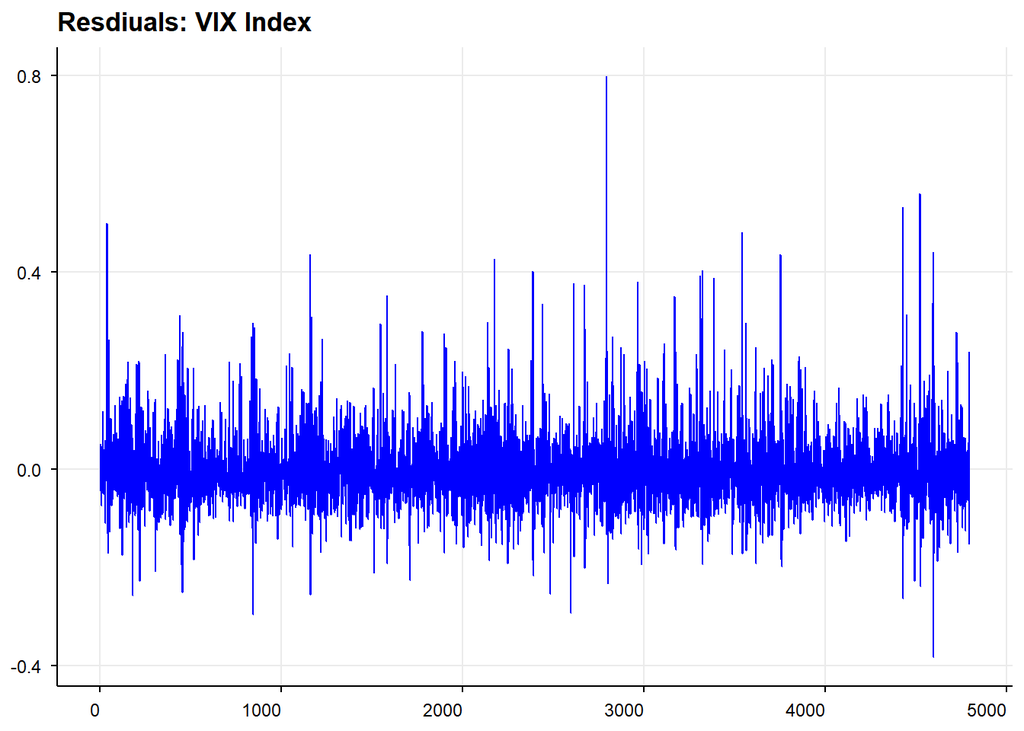

```r
# --- plot the residuals
plot_res(VIX_model, "VIX")
```

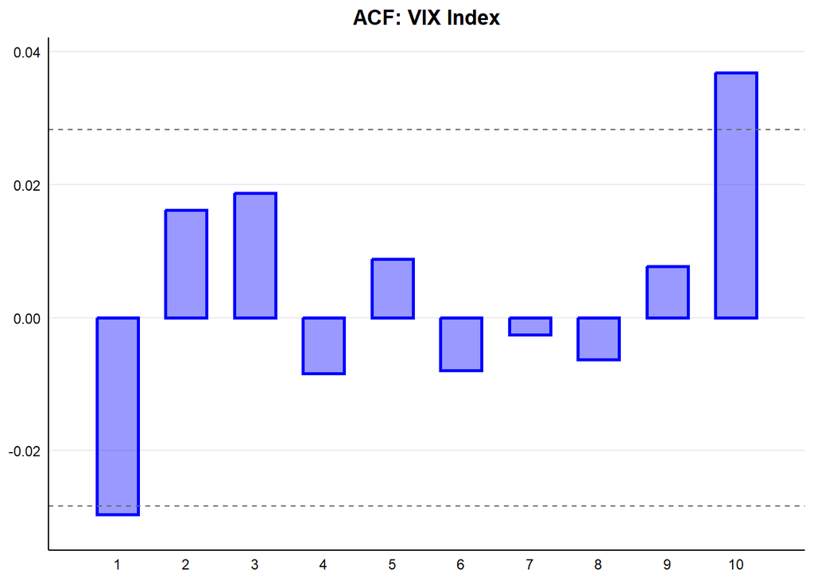

```r
# --- plot the ACF of the residuals
nice_acf(residuals(VIX_model),"VIX", residuals = TRUE)
```

```r
# --- Ljung-Box test (p-value > 0.05, fail to reject the null, residuals look like WN)
Box.test(residuals(VIX_model), lag=20, type = "Ljung-Box")
```

```
##
##  Box-Ljung test
##
## data:  residuals(VIX_model)
## X-squared = 17.423, df = 20, p-value = 0.6254
```

```r
# --- own automated loop to select p and q
fit_arma(VIX$lr)
```

```
## $aic
## [1] -11016.66
##
## $order
## [1] 1 0 2
##
## $model
##
## Call:
## arima(x = ts, order = final.order)
##
## Coefficients:
##          ar1      ma1     ma2  intercept
##       0.9311  -1.0378  0.0619      1e-04
## s.e.  0.0198   0.0250  0.0171      4e-04
##
## sigma^2 estimated as 0.005864:  log likelihood = 5513.33,  aic = -11016.66
```

```r
# --- forecast package function
auto.arima(VIX$lr, ic = "aic")
```

```
## Series: VIX$lr
## ARIMA(2,0,3) with zero mean
##
## Coefficients:
##          ar1     ar2      ma1      ma2     ma3
##       0.1771  0.7072  -0.2832  -0.7344  0.0572
## s.e.  0.2831  0.2599   0.2832   0.2840  0.0195
##
## sigma^2 = 0.005869:  log likelihood = 5513.79
## AIC=-11015.58   AICc=-11015.56   BIC=-10976.73
```

# Appendix

## AR(1)

$$y_{t} = c + \phi_1 y_{t-1} + \epsilon_t$$

Let’s work out the above expression.

$$\begin{align*}
y_t &= c + \phi_1 (c + \phi_1 y_{t-2} + \epsilon_{t-1}) + \epsilon_t
\\
&= c + \phi_1 c + \phi_{1}^{2} y_{t-2} + \phi_1 \epsilon_{t-1}
+ \epsilon_t \\
&= c + \phi_1 c + \phi_{1}^{2}(c + \phi_1 y_{t-3} +
\epsilon_{t-2}) + \phi_1 \epsilon_{t-1} + \epsilon_t \\
&= c + \phi_1 c + \phi_{1}^{2}c + \phi_{1}^{3}y_{t-3} +
\phi_{1}^{2} \epsilon_{t-2} + \phi_1 \epsilon_{t-1} + \epsilon_t \\
&= \dots \\
&= c \sum_{i=0}^{t-1}\phi_1^{i} + \phi_1^{t} y_0
+\sum_{i=0}^{t-1}\phi_1^{i} \epsilon_{t-i}
\end{align*}$$

With $|\phi_1| < 1$: $\lim_{t \to \infty} \phi_1^{t} y_0 = 0$. Also, with $t \to \infty$ and by the property of geometric series: $\sum_{i=0}^{\infty} \phi_1^{i} = \frac{1}{1 - \phi_1}$

Rewriting the above expression we have that
$$y_t = \frac{c}{1-\phi} + \sum_{i=0}^{\infty} \phi_1^{i} \epsilon_{t-i}$$

Therefore, the $AR(1)$ has a $MA(\infty)$ representation.

We can use this representation to write the following moments.

### Unconditional Mean

$$\begin{align*}
\mathbb{E}(y_t) &= \mathbb{E\left(\frac{c}{1-\phi_1} +
\sum_{i=0}^{\infty} \phi_1^{i} \epsilon_{t-i} \right)} \\
&= \frac{c}{1-\phi_1} + \sum_{i=0}^{\infty} \phi_1^{i}
\underbrace{\mathbb{E}(\epsilon_{t-i})}_{=0} \\
&= \frac{c}{1-\phi_1}
\end{align*}$$

### Unconditional Variance

$$\begin{align*}
\mathbb{Var}(y_t) &= \mathbb{E}[(y_t - \mathbb{E}(y_t))^2] \\
&= \mathbb{E}\left[\left(y_t - \frac{c}{1-\phi_1}\right)^2\right] \\
&= \mathbb{E}\left[\left(\sum_{i=0}^{\infty} \phi_1^{i}
\epsilon_{t-i}\right)^2\right] \\
\end{align*}$$

Let’s rewrite the expression inside the expectation operator.

$$\begin{align*}
\left(\sum_{i=0}^{\infty} \phi_1^{i} \epsilon_{t-i}\right)^2 &=
(\epsilon_{t} + \phi_1\epsilon_{t-1} + \phi_1^2\epsilon_{t-2} + \dots)^2
\\
&= \epsilon_t^2 + \phi_1 \epsilon_t\epsilon_{t-1} +
\phi_1^2\epsilon_t\epsilon_{t-2} + \dots +
\phi_1\epsilon_t\epsilon_{t-1} + \phi_1^2\epsilon_{t-1}^2 + \phi_1^3
\epsilon_{t-1}\epsilon_{t-2} +\dots + \phi_1^2\epsilon_t\epsilon_{t-2} +
\phi_1^3\epsilon_{t-1}\epsilon_{t-2} + \phi_1^4\epsilon_{t-2}^2 + \dots
\\
& = \epsilon_t^2 + \phi_1^2\epsilon_{t-1}^2 +
\phi_1^4\epsilon_{t-2}^2 + 2\phi_1\epsilon_t\epsilon_{t-1} +
2\phi_1^2\epsilon_t\epsilon_{t-2} +
2\phi_1^3\epsilon_{t-1}\epsilon_{t-2} + \dots \\
&= \sum_{i=0}^{\infty} \phi_1^{2i} \epsilon_{t-i}^2 +
\sum_{i=0}^{\infty} \sum_{j=0}^{\infty} \phi_1^{i+j}
\epsilon_{t-i}\epsilon_{t-j} \text{ , with } i \neq j
\end{align*}$$

Using this simplified expression,

$$\begin{align*}
\mathbb{Var}(y_t) &= \mathbb{E}\left[\sum_{i=0}^{\infty} \phi_1^{2i}
\epsilon_{t-i}^2 + \sum_{i=0}^{\infty} \sum_{j=0}^{\infty} \phi_1^{i+j}
\epsilon_{t-i}\epsilon_{t-j}\right] \\
&= \sum_{i=0}^{\infty} \phi_1^{2i} \mathbb{E}(\epsilon_{t-i}^2) +
\sum_{i=0}^{\infty} \sum_{j=0}^{\infty}
\mathbb{E}(\epsilon_{t-i}\epsilon_{t-j}) \\
&= \sum_{i=0}^{\infty} \phi_1^{2i} \mathbb{E}[(\epsilon_{t-i}-0)^2]
+ \sum_{i=0}^{\infty} \sum_{j=0}^{\infty}
\mathbb{E}[(\epsilon_{t-i}-0)(\epsilon_{t-i}-0)] \\
&= \underbrace{\sum_{i=0}^{\infty} \phi_1^{2i}
\underbrace{\mathbb{Var}(\epsilon_{t-i})}_{=\sigma^2}}_{\text{convergent
series to} \frac{1}{1-\phi_1^2}} + \sum_{i=0}^{\infty}
\sum_{j=0}^{\infty}
\underbrace{\mathbb{Cov}(\epsilon_{t-i},\epsilon_{t-i})}_{=0} \\
&= \frac{\sigma^2}{1-\phi_1^2}
\end{align*}$$

## ARMA(1,1)

$$y_t = c + \phi_1 y_{t-1} + \epsilon_t + \theta_1 \epsilon_{t-1}$$